# Prediction Assignment Writeup

João Wendt

06/08/2020

# Background

Using devices such as Jawbone Up, Nike FuelBand, and Fitbit it is now possible to collect a large amount of data about personal activity relatively inexpensively. These type of devices are part of the quantified self movement - a group of enthusiasts who take measurements about themselves regularly to improve their health, to find patterns in their behavior, or because they are tech geeks. One thing that people regularly do is quantify how much of a particular activity they do, but they rarely quantify how well they do it. In this project, your goal will be to use data from accelerometers on the belt, forearm, arm, and dumbell of 6 participants. They were asked to perform barbell lifts correctly and incorrectly in 5 different ways. More information is available from the website here: http://web.archive.org/web/20161224072740/http:/groupware.les.inf.puc-rio.br/har (see the section on the Weight Lifting Exercise Dataset).

# Data

The training data for this project are available here:

https://d396qusza40orc.cloudfront.net/predmachlearn/pml-training.csv

The test data are available here:

https://d396qusza40orc.cloudfront.net/predmachlearn/pml-testing.csv

The data for this project come from this source: http://web.archive.org/web/20161224072740/http:/groupware.les.inf.puc-rio.br/har. If you use the document you create for this class for any purpose please cite them as they have been very generous in allowing their data to be used for this kind of assignment.

# Data Processing

### Download the data from the provided URL, and load it into R

```r
library(caret)
library(corrplot)
library(rpart)
library(rattle)
trainUrl <- "https://d396qusza40orc.cloudfront.net/predmachlearn/pml-training.csv"
testUrl <- "https://d396qusza40orc.cloudfront.net/predmachlearn/pml-testing.csv"
trainFile <- "pml-trainging.csv"
testFile <- "pml-testing.csv"
if (!file.exists(trainFile)){download.file(trainUrl, trainFile, method = "curl")}
if (!file.exists(testFile)){download.file(testUrl, testFile, method = "curl")}
TrainData <- read.csv(trainFile)
TestData <- read.csv(testFile)
```

### Create a partition of the traning data set and clean data

```r
 # The training dataset is  partitioned into 2 to create a Training set with 70% of the data for the modeling process.  A Test set is created with the remaining 30% for the validations.
set.seed(32343)
inTrain <- createDataPartition(TrainData$classe, p = 0.7, list = FALSE)
trainData <- TrainData[inTrain, ]
testData <- TrainData[-inTrain, ]
dim(trainData)
```

```
## [1] 13737   160
```

```r
dim(testData)
```

```
## [1] 5885  160
```

```r
# trainData and testData have a large number of NA values and near-zero-variance (NZV) variables. Remove both.
NZV <- nearZeroVar(trainData)
trainData <- trainData[, -NZV]
testData  <- testData[, -NZV]
dim(trainData)
```

```
## [1] 13737   108
```

```r
dim(testData)
```

```
## [1] 5885  108
```

```r
# Remove variables that are mostly NA. A threshlod of 95 % is selected.
mostlyNA <- sapply(trainData, function(x) mean(is.na(x))) > 0.95
mostlyNATest <- sapply(testData, function(x) mean(is.na(x))) > 0.95
trainData <- trainData[, mostlyNA==F]
testData <- testData[, mostlyNATest==F]
dim(trainData)
```

```
## [1] 13737    59
```

```r
dim(testData)
```

```
## [1] 5885   59
```

```r
# Remove identification only variables (columns 1 to 5)The highly correlated variables are shown in dark colors in the graph above. To make an even more compact analysis, a PCA (Principal Components Analysis) could be performed as a pre-processing step to the datasets. Nevertheless, as the correlations are quite few, this step will not be applied for this assignment.
trainData <- trainData[, -(1:5)]
testData <- testData[, -(1:5)]
dim(trainData)
```

[output not shown]

[output not shown]

```
## [1] 13737    54
```

```r
dim(testData)
```

```
## [1] 5885   54
```

### Data Analysis

#### a) Check correlation among variables

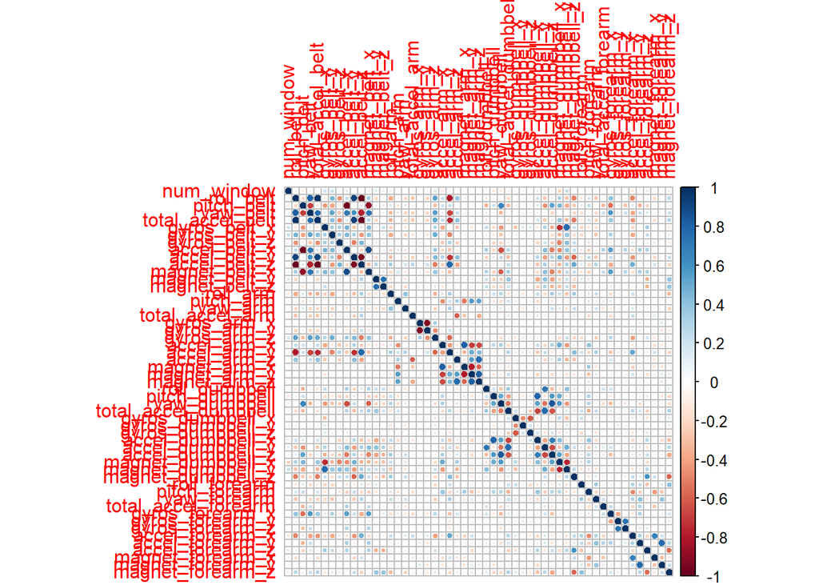

```r
correlation <- cor(trainData[, -54])
corrplot(correlation, method="circle")
```

```r
# The circles with dark colors show highly correlated variables in the graph above. Correlations do not seem to give any analysis points as they are very less.
```

#### b) Classification tree method

[figure not shown]

```r
trControl <- trainControl(method="cv", number=5)
model_CT <- train(classe~., method="rpart", data=trainData, trControl=trControl)
fancyRpartPlot(model_CT$finalModel)
```

```r
predict_train <- predict(model_CT,newdata=testData)
confMatClassTree <- confusionMatrix(table(testData$classe,predict_train))
#Display confusion matrix and model accuracy
confMatClassTree$table
```

```
##    predict_train
##        A    B    C    D    E
##   A 1517   28  123    0    6
##   B  481  384  274    0    0
##   C  475   26  525    0    0
##   D  405  175  334    0   50
##   E  131   86  233    0  632
```

```r
confMatClassTree$overall[1]
```

```
##  Accuracy
## 0.5196262
```